# R Notebook on Baseball Salaries Data

# Introduction and Data Summary

In this notebook we will carry out some analyses on the dataset Salaries.csv.

We begin ny loading the libraries we will use and importing the appropriate libraries. Namely, we load the tidyverse and reshape2 packages.

```r
library(tidyverse)
library(reshape2)
```

Next, import the data.

```r
salary_df <- read_csv("Data/Salaries.csv")
```

We should determine the size and column names of the dataframe.

```r
dim(salary_df)
```

```
[1] 24758     5
```

```r
names(salary_df)
```

```
[1] "yearID"   "teamID"   "lgID"     "playerID" "salary"
```

Then examine the first few and last few rows of the data.

```r
head(salary_df)
```

| yearID | teamID | lgID | playerID | salary |
| --- | --- | --- | --- | --- |
| 1985 | ATL | NL | barkele01 | 870000 |
| 1985 | ATL | NL | bedrost01 | 550000 |
| 1985 | ATL | NL | benedbr01 | 545000 |
| 1985 | ATL | NL | campri01 | 633333 |
| 1985 | ATL | NL | ceronri01 | 625000 |
| 1985 | ATL | NL | chambch01 | 800000 |

```r
tail(salary_df)
```

| yearID | teamID | lgID | playerID | salary |
| --- | --- | --- | --- | --- |
| 2014 | WAS | NL | stammcr01 | 1375000 |
| 2014 | WAS | NL | storedr01 | 3450000 |
| 2014 | WAS | NL | strasst01 | 3975000 |
| 2014 | WAS | NL | werthja01 | 20000000 |
| 2014 | WAS | NL | zimmejo02 | 7500000 |
| 2014 | WAS | NL | zimmery01 | 14000000 |

We can quickly obtain some summary statistics.

```r
summary(salary_df)
```

```
     yearID        teamID              lgID             playerID             salary
 Min.   :1985   Length:24758       Length:24758       Length:24758       Min.   :       0
 1st Qu.:1993   Class :character   Class :character   Class :character   1st Qu.:  260000
 Median :2000   Mode  :character   Mode  :character   Mode  :character   Median :  525000
 Mean   :2000                                                            Mean   : 1932905
 3rd Qu.:2007                                                            3rd Qu.: 2199643
 Max.   :2014                                                            Max.   :33000000
```

This tells us some useful information. First, we see the class of the five variables. Second, there is no missing data becuase otherwise this would have been indicated by the output from the summary function. In addition, we get the five mean and quantiles for the two numeric variables yearID and salary.

What information does this dataset seem to contain?

# Some Initial Plots

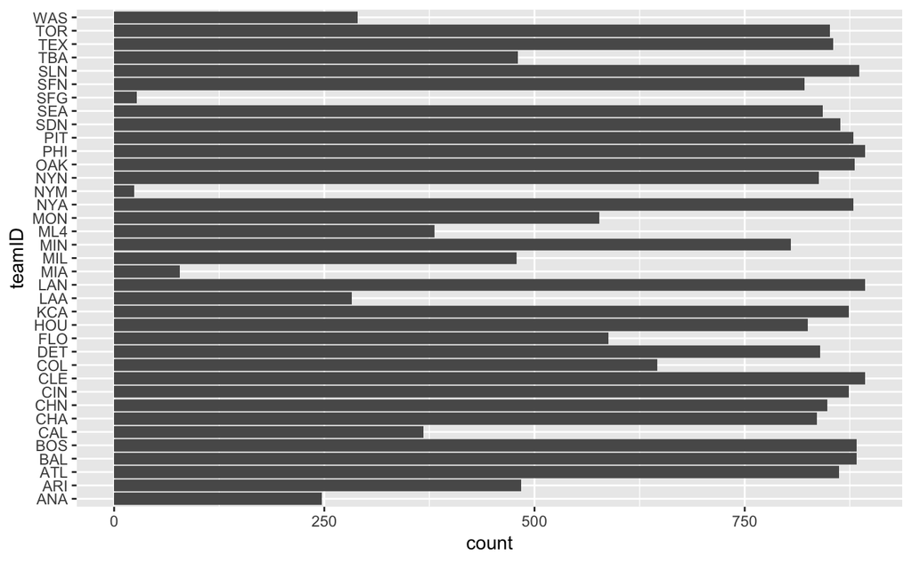

```r
salary_df %>% ggplot() + geom_bar(mapping = aes(x=teamID)) + coord_flip()
```

This shows how many observations there are for each of the 37 different teams. Notice that one way to determine how many distinct teams there are is to use the following command.

```r
salary_df$teamID %>% unique() %>% length()
```

```
[1] 37
```

# Examine Salaries by Year

```r
avg_sal_by_year <- salary_df %>% group_by(yearID) %>% summarize(avg_sal = mean(salary))
```

Let’s take a look.

```r
head(avg_sal_by_year)
```

| yearID | avg_sal |
| --- | --- |
| 1985 | 476299.4 |
| 1986 | 417147.0 |
| 1987 | 434729.5 |
| 1988 | 453171.1 |
| 1989 | 506323.1 |
| 1990 | 511973.7 |

We can kind of check this. For example keep only data with year 1985 and compute mean

```r
salary_df %>% filter(yearID == 1985) %>% select(salary) %>% unlist() %>% mean()
```

```
[1] 476299.4
```

This agrees with what we saw in the first row for avg_sal_by_year.

Now let’s plot the mean salary over time.

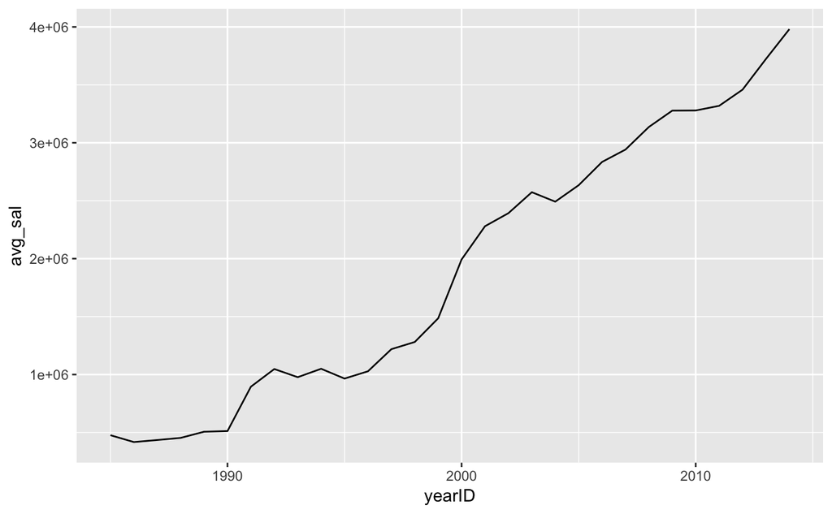

```r
avg_sal_by_year %>% ggplot(mapping = aes(x=yearID,y=avg_sal)) + geom_line()
```

What does this plot suggest?

# A Deeper Analysis

We should be careful regarding outliers so let’s look at the median too.

```r
sal_stats_by_year <- salary_df %>%
  group_by(yearID) %>%
  summarize(avg_sal = mean(salary), med_sal = median(salary))
```

We can plot both mean and median salaries over time but first we have to convert data to long format.

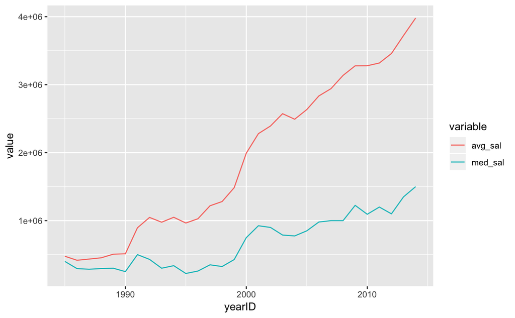

```r
sal_stats_by_year %>%
  melt(id="yearID") %>%
  ggplot(mapping=aes(x=yearID, y=value, colour=variable)) +
  geom_line()
```

What can you conclude?

It is easy to look at the salary distributions by team.

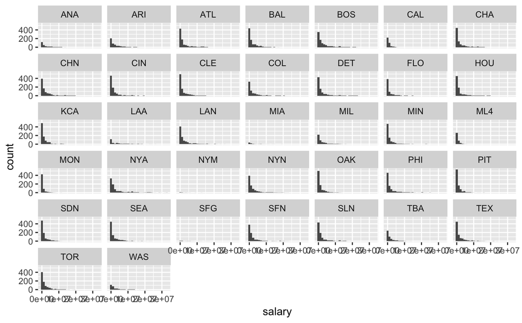

```r
salary_df %>% ggplot(mapping = aes(x=salary)) + geom_histogram() + facet_wrap(~ teamID)
```

Let’s write a function that plots the salary distribution for input year and team

```r
team_year_sal <- function(yearID_val,teamID_val){
  salary_df %>% filter(teamID==teamID_val,yearID == yearID_val) %>%
    ggplot(mapping = aes(x=salary)) +
    geom_histogram() +
    ggtitle(paste(as.character(yearID_val),teamID_val,sep=" "))
}
```

Example using the function.

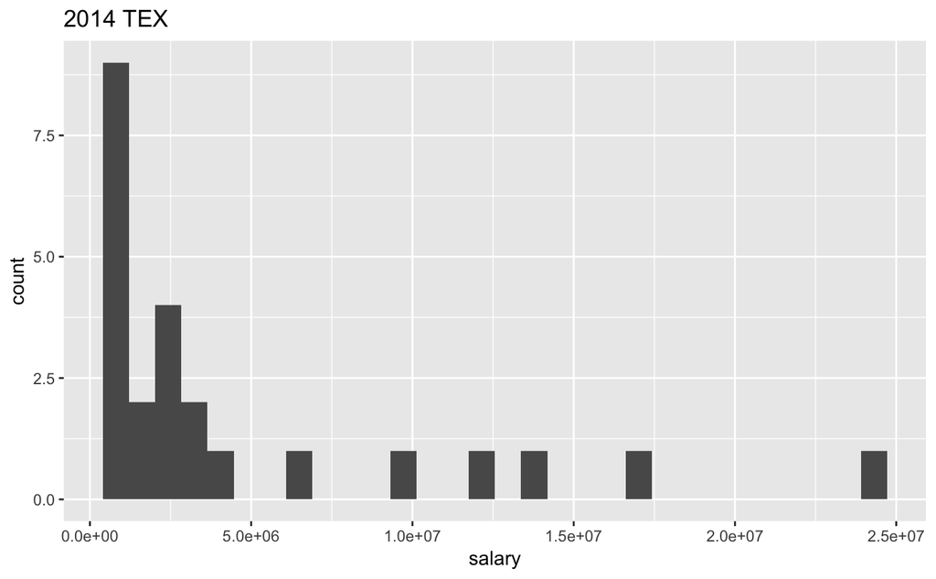

```r
team_year_sal(2014,"TEX")
```

Let’s do something similar but produce a boxplot instead.

```r
team_year_sal_box <- function(yearID_val,teamID_val){
  salary_df %>% filter(teamID==teamID_val,yearID == yearID_val) %>%
    ggplot(mapping = aes(y=salary)) +
    geom_boxplot() +
    ggtitle(paste(as.character(yearID_val),teamID_val,sep=" "))
}
```

Example using the function

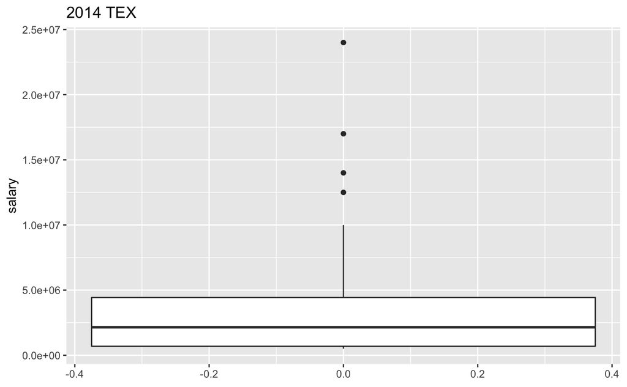

```r
team_year_sal_box(2014,"TEX")
```

Perhaps we can see the boxplots across all teams for a given year

```r
year_sal_box <- function(yearID_val){
  salary_df %>% filter(yearID == yearID_val) %>%
    ggplot(mapping = aes(x=teamID,y=salary)) +
    geom_boxplot() +
    coord_flip() +
    ggtitle(as.character(yearID_val))
}
```

Example using the function

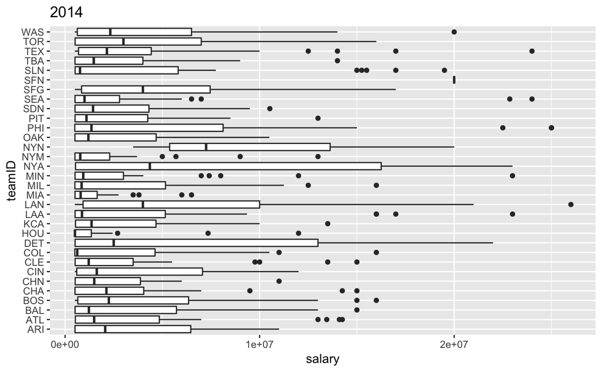

```r
year_sal_box(2014)
```

What can we see based on this?

Let’s find the total salary amount per team per year.

```r
tot_sal <- salary_df %>% group_by(yearID,teamID) %>% summarise(total_salary=sum(salary))
```

Take a look at result.

```r
head(tot_sal)
```

| yearID | teamID | total_salary |
| --- | --- | --- |
| 1985 | ATL | 14807000 |
| 1985 | BAL | 11560712 |
| 1985 | BOS | 10897560 |
| 1985 | CAL | 14427894 |
| 1985 | CHA | 9846178 |
| 1985 | CHN | 12702917 |

Let’s determine for each year which team spent the most:

```r
# First we find the max total salaries by year
tot_max <- tot_sal %>% group_by(yearID) %>% summarise(max_sal=max(total_salary))
# Then convert the max total salary values into a vector
max_vals <- tot_max$max_sal %>% unlist()
# Then pull out the rows where the max total salaries occur
high_price_teams <- tot_sal %>% filter(total_salary %in% max_vals)
```

Let’s look.

```r
head(high_price_teams)
```

| yearID | teamID | total_salary |
| --- | --- | --- |
| 1985 | ATL | 14807000 |
| 1986 | NYA | 18494253 |
| 1987 | NYA | 17099714 |
| 1988 | NYA | 19441152 |
| 1989 | LAN | 21071562 |
| 1990 | KCA | 23361084 |

What does the previous result tell us?

There’s only 30 rows and 3 columns so we can look at the entire result.

```r
View(high_price_teams)
```

Let’s plot the maximum total salaries over time.

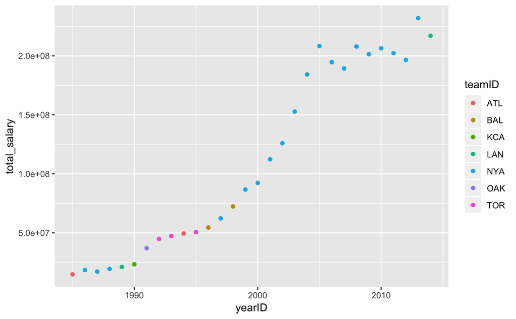

```r
high_price_teams %>%
  ggplot() +
  geom_point(mapping = aes(x=yearID,y=total_salary,color=teamID))
```

It could be useful to fit a curve through the data.

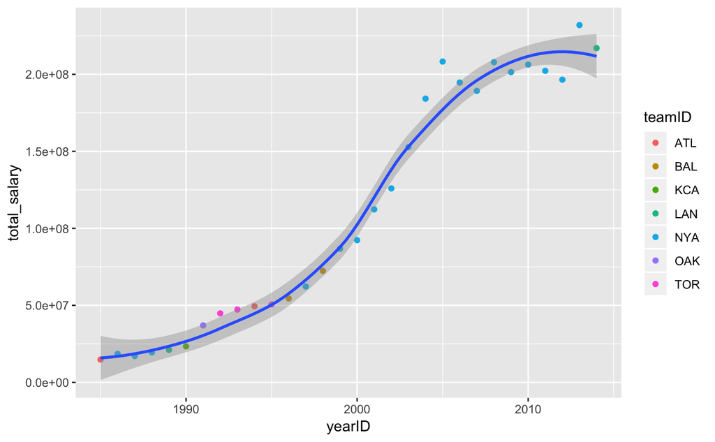

```r
high_price_teams %>%
  ggplot() +
  geom_point(mapping = aes(x=yearID,y=total_salary,color=teamID)) +
  geom_smooth(mapping = aes(y=total_salary, x=yearID))
```

It would be interesting to know the playoff and world series results for these high salary teams.